# Neural_Networks_Project

Neural Networks Project

### Objective

The objective is to train a multi-layered Neural Network to identity the Street View Housing Numbers (SVHN).

We will be using a dataset called SVHN....SVHN is obtained from house numbers in Google Street View images

Dataset has about 42000 images of street numbers with their labels. We'll train the network with these images. Then given an image, the network should be able to classify it as the right digit between 0-9

[figure not shown]

### Dataset Description

SVHN is a real-world image dataset for developing machine learning and object recognition algorithms with minimal requirement on data formatting but comes from a significantly harder, unsolved, real world problem (recognizing digits and numbers in natural scene images). SVHN is obtained from house numbers in Google Street View images.

The images come in two formats as follows.

Format 1 : Original images with character level bounding boxes.

Format 2 : MNIST-like 32-by-32 images centered around a single character (many of the images do contain some distractors at the sides).

```python
## Importing the necessary libraries.

import numpy as np
import pandas as pd
import warnings
warnings.filterwarnings('ignore')

# Visualization
import matplotlib.pyplot as plt
%matplotlib inline

# used to supress display of warnings
import warnings
warnings.filterwarnings('ignore')

import tensorflow
from tensorflow import keras
from keras import optimizers, regularizers
from keras.layers import Flatten, Dense, BatchNormalization, Dropout
from sklearn.model_selection import train_test_split
from keras.models import Sequential
from keras.utils.np_utils import to_categorical
```

## ● Read the data from the h5py file and understand the train/test splits (5 points)

```python
import h5py
h5 = h5py.File('SVHN_single_grey1.h5','r')

h5.keys()
```

```
<KeysViewHDF5 ['X_test', 'X_train', 'X_val', 'y_test', 'y_train', 'y_val']>
```

```python
X_train = h5['X_train']
y_train = h5['y_train']

X_test = h5['X_test']
y_test = h5['y_test']

X_val = h5['X_val']
y_val = h5['y_val']
```

```python
# Checking the shape of the dataset
print('X_train:', X_train.shape,'\n',
      'y_train:', y_train.shape,'\n\n',

      'X_test:',  X_test.shape,'\n',
      'y_test:',  y_test.shape,'\n\n',

      'X_val:',   X_val.shape,'\n',
      'y_val:',   y_val.shape,sep='')
```

```
X_train:(42000, 32, 32)
y_train:(42000,)

X_test:(18000, 32, 32)
y_test:(18000,)

X_val:(60000, 32, 32)
y_val:(60000,)
```

### The dataset contains 42000 training images size of 32*32 with their corresponding labels and 18000 test data points to check the model performance using accuracy metric

```
Label:  1
```

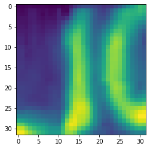

```python
## Displaying a random image from each of training and test sets to confirm if data is fetched correctly.

plt.imshow(X_train[15000])    # seeing some random number in the dataset
print('Label: ', y_train[15000])
```

## ● Reshape and normalize the train and test features (10 points)

```python
## Reshaping the data columns from 32×32 to 1024 features/columns in the dataset
## as a single array of data is to be set for the model training for each instance

X_train = X_train.value.reshape(42000, 1024) # 1024 which is of 32*32
print(X_train.shape)

X_test = X_test.value.reshape(18000, 1024)
print(X_test.shape)

X_val = X_val.value.reshape(60000, 1024)
print(X_val.shape)
```

```
(42000, 1024)
(18000, 1024)
(60000, 1024)
```

```python
# Normalizing the data from 0-255 to 0-1 by dividing the inputs by 255.

# Before normalising
print(X_train.max())
print(X_train.min())

X_train = X_train / 255.0
X_test = X_test / 255.0
X_val = X_val / 255.0

# After normalising
print(X_train.max())
print(X_train.min())
```

```
254.9745
0.0
0.9999
0.0
```

#### After normalizing we can see that all the values lies between 0 and 1

```python
# We should check the proportion of each class in the target variable
# to ensure there is no imbalance in the ground truth values.

l = pd.DataFrame(y_train)
l[0].value_counts()
```

```
3    4281
5    4232
2    4197
9    4196
7    4192
8    4188
4    4188
0    4186
1    4172
6    4168
Name: 0, dtype: int64
```

### It looks fine, all the labels are more or less equally distributed.

## ● One hot encode the labels for train and test data (15 points)

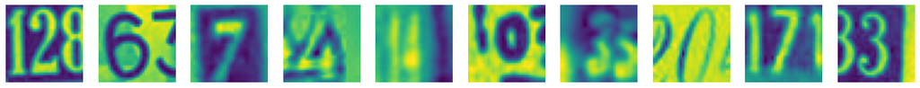

```
label for each of the above images: [2 6 7 4 4 0 3 0 7 3]
```

```python
# visualizing the first 10 images in the dataset and their labels

plt.figure(figsize=(20, 5))

for i in range(10):
    plt.subplot(1, 10, i+1)
    plt.imshow(X_train[i].reshape(32, 32))
    plt.axis('off')
plt.show()
print('label for each of the above images: {}'.format(y_train[0:10]))
```

Encoding the target variables. We need to one hot encode the labels for the model to understand the labels better. We will be using categorical cross entropy as our loss function and for this purpose we need our labels to be in one hot encoded format.

```python
# Before converting the labels to one hot encoder
print(y_train[10])

y_train = to_categorical(y_train, num_classes=10)
y_test = to_categorical(y_test, num_classes=10)
y_val = to_categorical(y_val, num_classes=10)

# After converting the labels to one hot encoder
print(y_train[10])
```

```
1
[0. 1. 0. 0. 0. 0. 0. 0. 0. 0.]
```

### One-hot encoding is essentially the representation of categorical variables as binary vectors. These categorical values are first mapped to integer values. Each integer value is then represented as a binary vector that is all 0s (except the index of the integer which is marked as 1).

## ● Define the model architecture using TensorFlow with a flatten layer followed by dense layers with activation as ReLu and softmax (15 points)

Linear layer, ReLU activation layer, Batch normalization layer classes are created along with cross entropy and softmax. Stochastic gradient descent function performs the back propagation with gradient flow through all the layers in reverse order. The original batch is divided into multiple mini batches with shuffled images and then each minibatch data is made to pass through layers in feedforward method and then back propagated after the loss is computed.

Sigmoid functions suffer from gradient vanishing problem, making training slower

ReLU (rectified linear unit) is one of the most popular ones, hence we will use ReLU

```python
# Creating a vannila models with simple dense neural network with less number of hidden layers
# and with no hyper parameters inside to check the model performance

# Initializing the constructor
model = Sequential()

# Defining the model architecture with 512 neurons in the first hidden layer
model.add(Dense(512, input_shape=(1024,), kernel_initializer='he_uniform', activation='relu'))

model.add(Dense(256,kernel_initializer='he_uniform', activation='relu'))

model.add(Dense(128,kernel_initializer='he_uniform', activation='relu'))

# Output layer with 10 neurons which is equal to 10 classes in the dataset
model.add(Dense(10, activation='softmax'))
```

```python
# Checking the summary of the model which shows number of parameters to learn and number of layers in the network
model.summary()
```

```
Model: "sequential"
_________________________________________________________________
Layer (type)                 Output Shape              Param #
=================================================================
dense (Dense)                (None, 512)               524800
_________________________________________________________________
dense_1 (Dense)              (None, 256)               131328
_________________________________________________________________
dense_2 (Dense)              (None, 128)               32896
_________________________________________________________________
dense_3 (Dense)              (None, 10)                1290
=================================================================
Total params: 690,314
Trainable params: 690,314
Non-trainable params: 0
_________________________________________________________________
```

```python
# Compiling the model with Categorical_crossentory as the loss function and using vanilla SGD as the optimizer technique
# and accuracy as the metric to check the model performance
model.compile(loss='categorical_crossentropy', optimizer='sgd', metrics=['accuracy'])
```

```python
# Running the model with 20 epochs and 200 as the batch size
history = model.fit(X_train, y_train, epochs=20, batch_size=200, validation_split=.2, verbose=1)
```

```python
# Checking the accuracy on test data
loss, accuracy = model.evaluate(X_test,y_test)
```

[output not shown]

### SGD is known for slow convergence hence model is performing poorly.

### We will try to change the optimizer to 'adam' and check the accuracy.

#

### Here Model architecture remains same, so the summary also, only changing optimizer

```python
# Creating a vannila model with simple dense neural network with less number of hidden layers
# and with no hyper parameters inside to check the model performance

# Initializing the constructor
model1 = Sequential()

# Defining the model architecture with 512 neurons in the first hidden layer
model1.add(Dense(512, input_shape=(1024,), kernel_initializer='he_uniform', activation='relu'))

# Adding input layer with activation function as Relu
# Using he_uniform technique for initializing the weights as it works best with relu activation function
model1.add(Dense(256,kernel_initializer='he_uniform', activation='relu'))

model1.add(Dense(128,kernel_initializer='he_uniform', activation='relu'))

# Output layer with 10 neurons which is equal to 10 classes in the dataset
model1.add(Dense(10, activation='softmax'))
```

```python
# Compiling the model with same parameters but with 'adam' optimizer
model1.compile(loss='categorical_crossentropy', optimizer='adam', metrics=['accuracy'])
```

```python
# Running the model with 20 epochs and 200 as the batch size
history1 = model1.fit(X_train, y_train, epochs=20, batch_size=200, validation_split=.2, verbose=1)
```

```python
# Checking the accuracy on test data using adam optimizer
loss, accuracy = model1.evaluate(X_test,y_test)
```

[output not shown]

### Adam optimizer is the powerful optimisation technique, Adam combines the best properties of the AdaGrad and RMSProp algorithms to provide an optimization algorithm that can handle sparse gradients on noisy problems.

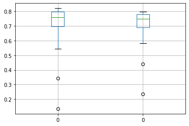

```python
# Here we are checking the training and validation accuracies to measure the performance of the model

# Dataframe to store training accuracy
ta = pd.DataFrame(history1.history['accuracy'])

# Dataframe to store validation accuracy
va = pd.DataFrame(history1.history['val_accuracy'])

# Concatinating both the dataframes
tva = pd.concat([ta,va], axis=1)

# Creating the boxplot to see the difference between both the accuracies
tva.boxplot()
```

### By observing the training and test accuracies using above two boxplots we can say that both are looking same and overlapping each other, hence model can be generalizable, where highesh accuracy is somewhere around 82%(training) and 79%(validation) and ~75% is the median score for both training and validation.

### We will try to improve the accuracy by adding more hidden layers and also by doing the hyper parameter tuning using grid search technique.

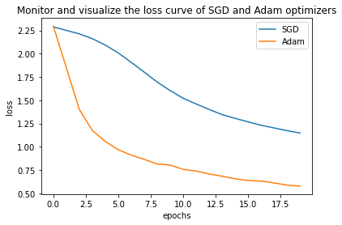

```python
plt.title('Monitor and visualize the loss curve of SGD and Adam optimizers')
plt.plot(history.history['loss'],label='SGD');
plt.plot(history1.history['loss'],label='Adam');
plt.xlabel('epochs')
plt.ylabel('loss')
plt.legend(loc='upper right');
```

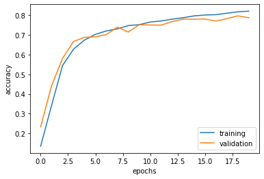

```python
# Training and validation accuracies across the epochs
plt.plot(ta,label='training');
plt.plot(va,label='validation');
plt.xlabel('epochs')
plt.ylabel('accuracy')
plt.legend(loc='lower right');
```

#### ---------------------------------------------------------------------------------------------------------------------------------------------------------------------------------------------------------------

### Here we will write a small class with one function to change the parameters and calling this function with different parameters to check the performance of the neural network model

```python
class NeuralNetwork():
    def __init__(self):
        self.m=[]
        self.n=[]

    def train_and_test_loop(self,iterations,Lambda,optimizers,verb=True):

        # Initializing the Artificial Neural Network Classifier (Sequential)
        model = Sequential()

        # Adding input layer with activation function Relu
        model.add(Dense(512, input_shape = (1024,), kernel_initializer='he_uniform', activation ='relu'))

        # Second hidden layer
        model.add(Dense(256, kernel_initializer='he_uniform', activation='relu'))

        # Third hidden layer
        model.add(Dense(128, kernel_initializer='he_uniform', activation='relu'))

        # Fourth hidden layer
        model.add(Dense(64, kernel_initializer='he_uniform', activation='relu'))

        # Output layer with softmax activation function
        model.add(Dense(10, activation='softmax',kernel_regularizer=regularizers.l2(Lambda)))

        # Compile model
        model.compile(optimizer = optimizers, loss='categorical_crossentropy', metrics=['accuracy'],)

        # Fit the model
        history = model.fit(X_train, y_train, epochs=iterations, validation_split=.2, batch_size=200, verbose= 1)

        # Storing all the accuracy across epochs
        self.m.append(history.history['accuracy'])
        self.n.append(history.history['val_accuracy'])

        # Checking accuracy on test set and corresponding loss
        loss, accuracy = model.evaluate(X_test, y_test, verbose=0)
        print('Test Accuracy: {:.2f}%'.format(accuracy*100))
        print('Test Loss: {:.3f}'.format(loss))
```

### Using 'SGD' optimizer to update the weights in each epoch and 'categorical_crossentropy' as loss function and 'accuracy' as the metric to monitor

```python
# creating an object for class to invoke the function inside it
sgd_model = NeuralNetwork()
Lambda = 1e-4
sgd = optimizers.SGD(lr=0.01)
sgd_model.train_and_test_loop(20, Lambda, sgd)
```

```
Test Accuracy: 66.93%
Test Loss: 1.096
```

### Loss is not decreasing and accuracy is slowly increasing as SGD is know to slow convergence even after using learning rate and optimization technques

### Even if we increase the number of epochs, accuracy would barely goes up (slowly)

##### --------------------------------------------------------------------------------------------------------------------------------------------------------------------

## ● Compile the model with loss as categorical cross-entropy and adam optimizers. Use accuracy as the metric for evaluation (10 points)

### Using 'adam' optimizer to update the weights in each epoch and 'categorical_crossentropy' as loss function and 'accuracy' as the metric to monitor

```python
# creating another object for class to invoke the function inside it
adam_model = NeuralNetwork()
Lamda = 1e-4
adam = optimizers.Adam(lr=0.001)
adam_model.train_and_test_loop(20, Lamda, adam)
```

```
Test Accuracy: 78.39%
Test Loss: 0.724
```

## ● Fit and evaluate the model. Print the loss and accuracy for the test data (5 points)

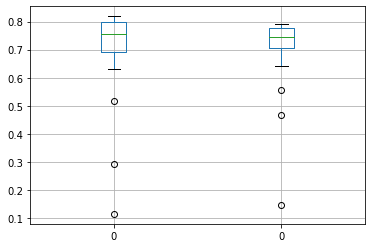

```python
# Here we are checking the training and validation accuracies to measure the performance of the model

# Dataframe to store training accuracy
ts = pd.DataFrame(list(np.array(adam_model.m).flatten()))

# Dataframe to store validation accuracy
vs = pd.DataFrame(list(np.array(adam_model.n).flatten()))

# Concatinating both the dataframes
tvs = pd.concat([ts,vs], axis=1)

# Creating the boxplot to see the difference between both the accuracies
tvs.boxplot()
```

### Will try to increase the number of epoch and see whether it performs even better or overfits?

```python
# creating another object for class to invoke the function inside it
adam_model2 = NeuralNetwork()
Lamda = 1e-4
adam2 = optimizers.Adam(lr=0.001)

# ObjectName.FunctionName to invoke the function inside the class
adam_model2.train_and_test_loop(50, Lamda, adam2)
```

```
Test Accuracy: 81.39%
Test Loss: 0.705
```

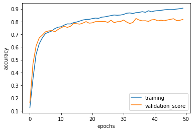

```python
plt.plot(list(np.array(adam_model2.m).flatten()),label='training');
plt.plot(list(np.array(adam_model2.n).flatten()),label='validation_score');
plt.xlabel('epochs')
plt.ylabel('accuracy')
plt.legend(loc='lower right');
```

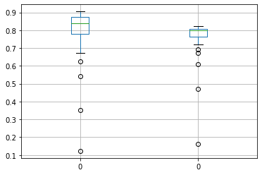

```python
# Here we are checking the training and validation accuracies to measure the performance of the model

# Dataframe to store training accuracy
ts = pd.DataFrame(list(np.array(adam_model2.m).flatten()))

# Dataframe to store validation accuracy
vs = pd.DataFrame(list(np.array(adam_model2.n).flatten()))

# Concatinating both the dataframes
tvs = pd.concat([ts,vs], axis=1)

# Creating the boxplot to see the difference between both the accuracies
tvs.boxplot()
```

### Above boxplot also tells the same, two boxplots are not much identical, hence we reduce the number of epochs or we can also use gridsearch to find out the optimal no. of epochs

#

### Using GridSearchCV from the sklearn package we try to fit the models with all the combinations specified as a parameter grid to find out best parameters which gives better accuracy.

### The Keras library provides wrapper classes to allow us to use neural network models developed with Keras in scikit-learn.

### KerasClassifier class in Keras can be used as an Estimator in scikit-learn, the base type of model in the library. The KerasClassifier takes the name of a function as an argument. This function must return the constructed neural network model, ready for training.

```python
from tensorflow.keras.wrappers.scikit_learn import KerasClassifier
from sklearn.model_selection import GridSearchCV

def create_model(layers, activation):
    model = Sequential()
    for i, nodes in enumerate(layers):

        # in the first iteration we will add the input layers with one hidden layer
        if i==0:
            model.add(Dense(nodes,input_dim=X_train.shape[1], activation=activation))

        # then from the next iterations we will be adding the number of hidden layers specified in the list
        else:

            model.add(Dense(nodes,activation=activation))
    # at last output layer
    model.add(Dense(10, activation='softmax')) # no activation beyond this point

    # compiling the model with the same parameters
    model.compile(optimizer='adam', loss='categorical_crossentropy',metrics=['accuracy'])
    return model

model = KerasClassifier(build_fn=create_model, verbose=1)
```

```python
# here minimum will be one hidden layer and max going to be 3 hidden layers
# and also the number of nodes in each hidden layers are the values in the list of tuples
layers = [(256,), (256, 128), (512, 256, 128)]

# checking with two activation functions
activations = ['relu', 'sigmoid']

# comibining both hyperparameters into one dictionary
param_grid = dict(layers=layers, activation=activations, batch_size = [256, 128], epochs=[20])

# instantiating the object for GridSearchCV method
grid = GridSearchCV(estimator=model, param_grid=param_grid)
```

```python
# Fitting the model with training data
grid_result = grid.fit(X_train, y_train)
```

```python
# Checking the best score and associated parameters
[grid_result.best_score_,grid_result.best_params_]
```

```
[0.7892381072044372,
 {'activation': 'relu',
  'batch_size': 128,
  'epochs': 20,
  'layers': (512, 256, 128)}]
```

```python
# Checking the score of the test data
grid_result.score(X_test,y_test)
```

```
0.746833324432373
```

[output not shown]

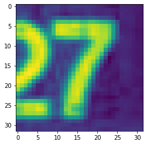

```python
# Predicting random test data point with the actual value in the test set
print('\nprediction:',grid_result.predict(X_test)[4200])

# Seeing the actual image and label
print('actual',np.argmax(y_test[4200]))
plt.imshow(X_test[4200].reshape(32,32));
```

```python
## It is correct
```

```python
# Creating a model with the parameters obtained from gridsearch to see the performance

# Initializing the constructor
model = Sequential()

# Defining the model architecture with 512 neurons in the first hidden layer
model.add(Dense(512, input_shape=(1024,), kernel_initializer='he_uniform',activation='relu'))

model.add(Dense(256, kernel_initializer='he_uniform', activation='relu'))

model.add(Dense(128, kernel_initializer='he_uniform', activation='relu'))

# Output layer with 10 neurons which is equal to 10 classes in the dataset
model.add(Dense(10, kernel_initializer='he_uniform', activation='softmax'))

model.compile(loss='categorical_crossentropy', optimizer='adam', metrics='accuracy')

history = model.fit(X_train, y_train, epochs=20, batch_size=200, validation_split=0.2, verbose=1)
```

```python
# Checking accuracy on test set and corresponding loss
loss, accuracy = model.evaluate(X_test, y_test, verbose=0)
print('Accuracy: {:.2f}%'.format(accuracy*100))
print('Loss: {:.3f}'.format(loss))
```

```
Accuracy: 78.14%
Loss: 0.743
```

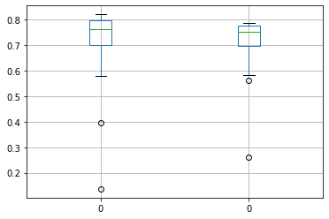

```python
# Here we are checking the training and validation accuracies to measure the performance of the model

# Dataframe to store training accuracy
ts = pd.DataFrame(history.history['accuracy'])

# Dataframe to store validation accuracy
vs = pd.DataFrame(history.history['val_accuracy'])

# Concatinating both the dataframes
tvs = pd.concat([ts,vs], axis=1)

# Creating the boxplot to see the difference between both the accuracies
tvs.boxplot()
```

### Using Hyperparameters tuning technique though we are not getting high accuracy but the model is not overfitting

```python
# Prediction
y_predict = model.predict(X_test)
```

```python
from sklearn.metrics import confusion_matrix, accuracy_score
```

```python
# Taking max of individual prediction scores and storing it
y_pred = []
for i in y_predict:
    y_pred.append(np.argmax(i))
```

```python
# Converting back from one hot to single values i.e 0-9
y_test1 =[]
for j in y_test:
    y_test1.append(np.argmax(j))
```

```python
# Creating confusion matrix to compare between actuals and predictions
cm = confusion_matrix(y_test1,y_pred)
print(cm)
```

```
[[1480   60   20   33   40   10   49   43   19   60]
 [  20 1533   25   33   98    8   12   65   13   21]
 [  21   39 1401   56   42   18    8  160   14   44]
 [  20   89   60 1264   34  111   21   74   17   29]
 [  27   65   40   18 1555   19   26   16    8   38]
 [  27   52   26  125   39 1319   61   27   47   45]
 [  89   45   27   33   94   57 1385   17   71   14]
 [  13   85   85   26   23   15    9 1523    9   20]
 [  50   71   57   66   60   47   89   33 1264   75]
 [  69   69   52   62   50   48   16   57   39 1342]]
```

## Batch Normalization:

### Here we are introducing the regularization techniques called Batchnormalization and Dropout

### Batch normalization is applied to the layers that we choose to apply it within our network. It normalises the outputs of the previous layer i.e o/p's of the activation function

### This process makes that the weights within the netowrk dont become imbalance with extremely high or low values since the normalisation is included in the gradient process

## Dropout:

### It is a also a regularizatin technique. All that it does is dropping a percentage(user_defined) of neurons from every layer.

### These techniques reduces overfitting problem

```python
keras_model = Sequential()

# Input Layer
#Adding Input layer and activation functions ReLU
keras_model.add(Dense(512, kernel_initializer='he_normal',input_shape = (1024,), activation ='relu'))
#Adding BatchNormalization Layer
keras_model.add(BatchNormalization())
#Adding dropout of 20%
keras_model.add(Dropout(0.2))

#Hidden Layer 1
#Adding first Hidden layer
keras_model.add(Dense(256, activation ='relu', kernel_initializer='he_normal'))
#Adding BatchNormalization Layer
keras_model.add(BatchNormalization())
#Adding dropout of 20%
keras_model.add(Dropout(0.2))

#Hidden Layer 2
#Adding second Hidden layer
keras_model.add(Dense(128, activation ='relu', kernel_initializer='he_normal'))
#Adding BatchNormalization Layer
keras_model.add(BatchNormalization())
#Adding dropout of 20%
keras_model.add(Dropout(0.2))

#Hidden Layer 3
#Adding third Hidden layer
keras_model.add(Dense(64, activation ='relu', kernel_initializer='he_normal'))
#Adding BatchNormalization Layer
keras_model.add(BatchNormalization())
keras_model.add(Dropout(0.2))

# #Hidden Layer 4
# #Adding fourth Hidden layer
# keras_model.add(Dense(32, activation ='relu', kernel_initializer='he_normal'))
# #Adding BatchNormalization Layer
# keras_model.add(BatchNormalization())
# #Adding dropout of 20%
# keras_model.add(Dropout(0.2))

# Output Layer
#Adding output layer which is of 10 nodes (digidts)
keras_model.add(Dense(10, activation='softmax'))
```

```python
#Setting the learning rate in sgd
adam = optimizers.Adam(lr = 0.0001)
# compiling the ANN classifier
keras_model.compile(optimizer = adam, loss = 'categorical_crossentropy', metrics = ['accuracy'])
```

```python
# Fitting the ANN to the Training data
history_2 = keras_model.fit(X_train, y_train, validation_data=(X_val,y_val),batch_size = 200, epochs = 50, verbose = 1)
```

```python
# Checking accuracy on test set and corresponding loss
loss, accuracy = keras_model.evaluate(X_test, y_test, verbose=0)
print('Accuracy: {:.2f}%'.format(accuracy))
print('Loss: {:.3f}'.format(loss))
```

```
Accuracy: 0.79%
Loss: 0.669
```

```python
# Prediction
y_predict1 = keras_model.predict(X_test)
# Taking max of individual prediction scores and storing it
y_pred1 = []
for i in y_predict1:
    y_pred1.append(np.argmax(i))
```

```python
# Creating confusion matrix to compare between actuals and predictions
cm = confusion_matrix(y_test1,y_pred1)
print(cm)
```

```
[[1480   13   17   33   32   14  106   21   36   62]
 [  29 1336   36  150   82   46   48   40   43   18]
 [  16   13 1469  108   24   28   21   62   33   29]
 [  19   13   48 1366   19  146   24   29   39   16]
 [  20   23   40   45 1530   30   62   12   26   24]
 [   8    8   18  102   20 1464   80   14   38   16]
 [  24   13   20   26   59   92 1507    7   70   14]
 [  14   34   96   93   18   24   26 1473   12   18]
 [  22   17   46   92   27  100  144    9 1325   30]
 [  89   20   26   80   36  100   35   30   81 1307]]
```

### Future implementations to get more accuracy:

- We could try with range of learning rate values and weight decay using gridsearch technique. ( requires more training time )
- Try other optimizers like RMSPROP, ADADELTA..etc
- We can use 'momentum' parameter which reduces the training time..
- Here because of the dataset is contained with distractors we could not able to get the high accuracy as with MNIST Dataset